# Big Data Academy Módulo R

##### 3.4.2.1.2 Datas

O R possui uma classe própria para objetos que armazenam datas. De modo que para transformar um elemento para tal classe podemos utilizar a função `as.Date()`:

```r
  ex_date <- as.Date(c("1988-03-25", "2019-03-25"))
  typeof(ex_date)
  #> [1] "double"
  class(ex_date)
  #> [1] "Date"
```

Ou ainda:

```r
  as.Date("01/12/2012", format = "%d/%m/%Y")
  #> [1] "2012-12-01"
```

Abaixo estão listadas algumas outras alternativas de formato - para mais opções consulte `?strptime`:

- %d: dias numéricos (0-31)
- %a: dias da semana, abreviados (Mon)
- %A: dias da semana, não abreviados (Monday)
- %m: meses numéricos (00-12)
- %b: meses em texto, abreviados (Jan)
- %B: meses em texto, não abreviados (January)
- %y: anos com dois dígitos (19)
- %Y: anos com quatro dígitos (2019)

Desta forma podemos fazer cálculos cabíveis à dados desta natureza, como, por exemplo, a quantidade de dias entre duas datas:

```r
  ex_date[1] - ex_date[2]
  #> Time difference of -11322 days
```

#### 3.4.2.2 Matrizes e arrays

Matrizes são estruturas que nos permitem trabalhar com dados bidimensionais que contenham o mesmo tamanho e o mesmo tipo de dados. Arrays são similares, porém permitindo mais que duas dimensões. Para criar uma matriz, podemos ou atribuir o atributo dimensão a um vetor, por meio da função `dim()`, ou reorganizar um vetor por meio de funções específicas:

```r
  x <- 1:8

#criando uma matriz a partir da atribuição de dimensões
  dim(x) <- c(2,4); x
  #>      [,1] [,2] [,3] [,4]
  #> [1,]    1    3    5    7
  #> [2,]    2    4    6    8

#ou definindo uma matriz a partir do número de linhas
  matrix(x, nrow = 2)
  #>      [,1] [,2] [,3] [,4]
  #> [1,]    1    3    5    7
  #> [2,]    2    4    6    8
  matrix(x, nrow = 2, byrow = TRUE)
  #>      [,1] [,2] [,3] [,4]
  #> [1,]    1    2    3    4
  #> [2,]    5    6    7    8

#pelo número de colunas
  matrix(x, ncol = 2)
  #>      [,1] [,2]
  #> [1,]    1    5
  #> [2,]    2    6
  #> [3,]    3    7
  #> [4,]    4    8

#ou ainda, ambos
  ex_matriz <- matrix(x, 2, 4); ex_matriz
  #>      [,1] [,2] [,3] [,4]
  #> [1,]    1    3    5    7
  #> [2,]    2    4    6    8
```

No caso da criação de um array é necessário definir um vetor como primeiro argumento, e um vetor com as dimensões como segundo:

```r
  ex_array <- array(x, dim = c(2, 2, 2)); ex_array
  #> , , 1
  #>
  #>      [,1] [,2]
  #> [1,]    1    3
  #> [2,]    2    4
  #>
  #> , , 2
  #>
  #>      [,1] [,2]
  #> [1,]    5    7
  #> [2,]    6    8
```

- **Consultas**

A consulta de valores se dá de modo similar aos vetores, com a diferença de precisarmos identificar qual a dimensão que estamos interessados, utilizando vírgulas para separar as dimensões, especificadas em ordem crescente:

```r
#matriz
  ex_matriz[1,1]
  #> [1] 1
#array - consulta do valor contido no cruzamento do primeiro elemento das três dimensões
  ex_array[1,1,1]
  #> [1] 1
#array - consulta do valor contido no primeiro elemento da terceira dimensão
  ex_array[ , ,1]
  #>      [,1] [,2]
  #> [1,]    1    3
  #> [2,]    2    4

#podemos também consultar informações como a dimensão do objeto
  dim(ex_array)
  #> [1] 2 2 2
```

- **Classe**

Estas estruturas possuem classes próprias:

```r
  class(ex_matriz)
  #> [1] "matrix"
  class(ex_array)
  #> [1] "array"
```

- **Operações**

Em relação às operações, as matrizes e arrays funcionam similarmente aos vetores, além de permitirem cálculos algébricos:

```r
#operações entre objetos
  rep(2,4) * ex_array
  #> , , 1
  #>
  #>      [,1] [,2]
  #> [1,]    2    6
  #> [2,]    4    8
  #>
  #> , , 2
  #>
  #>      [,1] [,2]
  #> [1,]   10   14
  #> [2,]   12   16

#matriz transposta
  t(ex_matriz)
  #>      [,1] [,2]
  #> [1,]    1    2
  #> [2,]    3    4
  #> [3,]    5    6
  #> [4,]    7    8

#multiplicação matricial
  ex_matriz %*% t(ex_matriz)
  #>      [,1] [,2]
  #> [1,]   84  100
  #> [2,]  100  120
```

#### 3.4.2.3 Data frames

Data Frames são estruturas bidimensionais mais genéricas que as matrizes, uma vez que as colunas podem conter tipos de objetos diferentes. Tais estruturas, similares a uma tabela SQL ou uma planilha do Excel, são usualmente o formato utilizado ao se importar dados para o R:

```r
#é possível criar data frames a partir de objetos existentes
  idade <- c(31,30,25,40)
  classe <- factor(c("AB", "C", "C", "B"), ordered = T)
  flag <- c(TRUE,TRUE,NA,FALSE)
  ex_df <- data.frame(idade,classe,flag); ex_df
  #>   idade classe  flag
  #> 1    31     AB  TRUE
  #> 2    30      C  TRUE
  #> 3    25      C    NA
  #> 4    40      B FALSE

#ou diretamente, especificando, ou não, o nome das colunas
  data.frame(nome_da_coluna1 = 1:3, 4:6)
  #>   nome_da_coluna1 X4.6
  #> 1               1    4
  #> 2               2    5
  #> 3               3    6
```

- **Consulta**  
  Com consultas similares às que vimos para as demais estruturas, um data.frame permite consultas especificando entre colchetes as linhas e colunas, respectivamente, separados por uma vírgula:

```r
#vetores de índice:
  ex_df[2,2]
  #> [1] C
  #> Levels: AB < B < C
  ex_df[c(2,4),]
  #>   idade classe  flag
  #> 2    30      C  TRUE
  #> 4    40      B FALSE
  ex_df[1,1:2]
  #>   idade classe
  #> 1    31     AB

#nomenclatura:
  ex_df$idade
  #> [1] 31 30 25 40
  ex_df[c("idade","classe")]
  #>   idade classe
  #> 1    31     AB
  #> 2    30      C
  #> 3    25      C
  #> 4    40      B

#vetores lógicos, e combinando as opções anteriores:
  ex_df[ex_df$idade>30,1]
  #> [1] 31 40
  ex_df[rownames(ex_df)==4,]
  #>   idade classe  flag
  #> 4    40      B FALSE
  ex_df[which(flag==TRUE),]
  #>   idade classe flag
  #> 1    31     AB TRUE
  #> 2    30      C TRUE
```

- **Classe**  
  Os Data Frames possuem uma classe própria, podendo ser consultada via `is.data.frame()` ou aderida com `as.data.frame()`. Porém, em ambos os casos, os elementos do data.frame permanecem com as suas próprias classes:

```r
  class(ex_df)
  #> [1] "data.frame"
  class(ex_df$idade)
  #> [1] "numeric"
```

- **Operações**

Aqui temos todas as opções já discutidas, tendo como restrição apenas se o tipo de objeto é cabível:

```r
  ex_df$idade + 1
  #> [1] 32 31 26 41
  ex_df$classe == "C"
  #> [1] FALSE  TRUE  TRUE FALSE
```

#### 3.4.2.4 Listas

Listas são estruturas também de uma dimensão, similarmente aos vetores, porém permitindo que diferentes tipos de objetos sejam guardados em um único vetor. Para a construção de listas utilizamos `list()` ao invés de `c()` - além de termos as opções `is.list()` e `as.list()`:

```r
  list(4L, "a", TRUE)
  #> [[1]]
  #> [1] 4
  #>
  #> [[2]]
  #> [1] "a"
  #>
  #> [[3]]
  #> [1] TRUE
```

Listas são também conhecidas como vetores recursivos, isto porque uma lista pode conter outras listas, de diferentes tamanhos. Tal característica permite que sua dimensão seja ampliada, e esta possa conter inclusive data frames:

```r
  ex_list <- list(9:1, ex_df = ex_df, TRUE)
  ex_list
  #> [[1]]
  #> [1] 9 8 7 6 5 4 3 2 1
  #>
  #> $ex_df
  #>   idade classe  flag
  #> 1    31     AB  TRUE
  #> 2    30      C  TRUE
  #> 3    25      C    NA
  #> 4    40      B FALSE
  #>
  #> [[3]]
  #> [1] TRUE
```

Por tais características listas são as estruturas mais genéricas no contexto de dados.

- **Consultas**

Para consultar elementos de uma lista, podemos seguir o padrão dos vetores usando `[`, tendo sempre listas como retorno. Ou por meio de `[[` - ou `$` caso os elementos sejam nomeados - tendo como retorno a classe do elemento consultado:

```r
  ex_list[1] ; class(ex_list[1])
  #> [[1]]
  #> [1] 9 8 7 6 5 4 3 2 1
  #> [1] "list"
  ex_list[[1]] ; class(ex_list[[1]])
  #> [1] 9 8 7 6 5 4 3 2 1
  #> [1] "integer"
  ex_list$ex_df ; class(ex_list$ex_df)
  #>   idade classe  flag
  #> 1    31     AB  TRUE
  #> 2    30      C  TRUE
  #> 3    25      C    NA
  #> 4    40      B FALSE
  #> [1] "data.frame"
```

Podemos também acessar os elementos de cada um dos sub-objetos, seguindo o padrão de consultas das suas estruturas originais:

```r
  ex_list[[1]][1]
  #> [1] 9
  ex_list$ex_df[1,1]
  #> [1] 31
```

- **Classe**

Listas possuem uma classe própria e, assim como o data frame, permite que seus elementos mantenham as suas próprias classes:

```r
  class(ex_list)
  #> [1] "list"
  class(ex_list[[1]])
  #> [1] "integer"
  class(ex_list$ex_df)
  #> [1] "data.frame"
  class(ex_list[[3]])
  #> [1] "logical"
```

- **Operações**

Listas seguem a mesma lógica dos vetores e data.frames em relação às operações, com esquema de reciclagem e coerção:

```r
#operação entre elementos da lista
 paste(ex_list[[1]][1:4], ex_list[[3]])
  #> [1] "9 TRUE" "8 TRUE" "7 TRUE" "6 TRUE"

#operação com uma coluna específica do data frame
 ex_list$ex_df$idade + ex_list[[1]]
  #> Warning in ex_list$ex_df$idade + ex_list[[1]]: comprimento do objeto maior
  #> não é múltiplo do comprimento do objeto menor
  #> [1] 40 38 32 46 36 34 28 42 32
```

> Para tirar dúvidas sobre como consultar os diferentes tipos de objetos no R utilize consulte o help `?Extract` ou `?Syntax`.

## 3.5 Analisando dados

Agora que temos familiaridade com os dados no R, vamos análisar uma base de dados do próprio R, visando apresentar algumas das funções *built-in* disponibilizadas para tal, bem como apresentar formas de importar/exportar dados.

### 3.5.1 Análises Descritivas

Iremos trabalhar com a base `mtcars`, uma das bases disponíveis por default no R. Por se tratar de uma base *built-in*, apesar dela ser normalmente retornada no console, para que ela conste como um dos objetos no `Environment` da sessão de trabalho, o seguinte comando é necessário: `data(mtcars)`. Para mais detalhes sobre a referida base de dados, contulte: `?mtcars`.

```r
#base para exemplo
  mtcars
  #>                      mpg cyl  disp  hp drat    wt  qsec vs am gear carb
  #> Mazda RX4           21.0   6 160.0 110 3.90 2.620 16.46  0  1    4    4
  #> Mazda RX4 Wag       21.0   6 160.0 110 3.90 2.875 17.02  0  1    4    4
  #> Datsun 710          22.8   4 108.0  93 3.85 2.320 18.61  1  1    4    1
  #> Hornet 4 Drive      21.4   6 258.0 110 3.08 3.215 19.44  1  0    3    1
  #> Hornet Sportabout   18.7   8 360.0 175 3.15 3.440 17.02  0  0    3    2
  #> Valiant             18.1   6 225.0 105 2.76 3.460 20.22  1  0    3    1
  #> Duster 360          14.3   8 360.0 245 3.21 3.570 15.84  0  0    3    4
  #> Merc 240D           24.4   4 146.7  62 3.69 3.190 20.00  1  0    4    2
  #> Merc 230            22.8   4 140.8  95 3.92 3.150 22.90  1  0    4    2
  #> Merc 280            19.2   6 167.6 123 3.92 3.440 18.30  1  0    4    4
  #> Merc 280C           17.8   6 167.6 123 3.92 3.440 18.90  1  0    4    4
  #> Merc 450SE          16.4   8 275.8 180 3.07 4.070 17.40  0  0    3    3
  #> Merc 450SL          17.3   8 275.8 180 3.07 3.730 17.60  0  0    3    3
  #> Merc 450SLC         15.2   8 275.8 180 3.07 3.780 18.00  0  0    3    3
  #> Cadillac Fleetwood  10.4   8 472.0 205 2.93 5.250 17.98  0  0    3    4
  #> Lincoln Continental 10.4   8 460.0 215 3.00 5.424 17.82  0  0    3    4
  #> Chrysler Imperial   14.7   8 440.0 230 3.23 5.345 17.42  0  0    3    4
  #> Fiat 128            32.4   4  78.7  66 4.08 2.200 19.47  1  1    4    1
  #> Honda Civic         30.4   4  75.7  52 4.93 1.615 18.52  1  1    4    2
  #> Toyota Corolla      33.9   4  71.1  65 4.22 1.835 19.90  1  1    4    1
  #> Toyota Corona       21.5   4 120.1  97 3.70 2.465 20.01  1  0    3    1
  #> Dodge Challenger    15.5   8 318.0 150 2.76 3.520 16.87  0  0    3    2
  #> AMC Javelin         15.2   8 304.0 150 3.15 3.435 17.30  0  0    3    2
  #> Camaro Z28          13.3   8 350.0 245 3.73 3.840 15.41  0  0    3    4
  #> Pontiac Firebird    19.2   8 400.0 175 3.08 3.845 17.05  0  0    3    2
  #> Fiat X1-9           27.3   4  79.0  66 4.08 1.935 18.90  1  1    4    1
  #> Porsche 914-2       26.0   4 120.3  91 4.43 2.140 16.70  0  1    5    2
  #> Lotus Europa        30.4   4  95.1 113 3.77 1.513 16.90  1  1    5    2
  #> Ford Pantera L      15.8   8 351.0 264 4.22 3.170 14.50  0  1    5    4
  #> Ferrari Dino        19.7   6 145.0 175 3.62 2.770 15.50  0  1    5    6
  #> Maserati Bora       15.0   8 301.0 335 3.54 3.570 14.60  0  1    5    8
  #> Volvo 142E          21.4   4 121.0 109 4.11 2.780 18.60  1  1    4    2
```

O primeiro ponto é como ter uma visão geral dos dados, para tal temos algumas opções como:

- `head()` - que retorna as primeiras linhas da base de dados, ou similarmente a função `tail()` que contempla as últimas linhas:

```r
head(mtcars)
  #>                    mpg cyl disp  hp drat    wt  qsec vs am gear carb
  #> Mazda RX4         21.0   6  160 110 3.90 2.620 16.46  0  1    4    4
  #> Mazda RX4 Wag     21.0   6  160 110 3.90 2.875 17.02  0  1    4    4
  #> Datsun 710        22.8   4  108  93 3.85 2.320 18.61  1  1    4    1
  #> Hornet 4 Drive    21.4   6  258 110 3.08 3.215 19.44  1  0    3    1
  #> Hornet Sportabout 18.7   8  360 175 3.15 3.440 17.02  0  0    3    2
  #> Valiant           18.1   6  225 105 2.76 3.460 20.22  1  0    3    1
tail(mtcars)
  #>                 mpg cyl  disp  hp drat    wt qsec vs am gear carb
  #> Porsche 914-2  26.0   4 120.3  91 4.43 2.140 16.7  0  1    5    2
  #> Lotus Europa   30.4   4  95.1 113 3.77 1.513 16.9  1  1    5    2
  #> Ford Pantera L 15.8   8 351.0 264 4.22 3.170 14.5  0  1    5    4
  #> Ferrari Dino   19.7   6 145.0 175 3.62 2.770 15.5  0  1    5    6
  #> Maserati Bora  15.0   8 301.0 335 3.54 3.570 14.6  0  1    5    8
  #> Volvo 142E     21.4   4 121.0 109 4.11 2.780 18.6  1  1    4    2
```

- `str()` - exibe a estrutura interna de um objeto, no caso da base de dados que estamos trabalhando p.e., temos: a estrutura dos dados (data.frame), o número de linhas (32 observações) e colunas (11 variáveis), além da classe de cada uma das colunas, e uma amostra das primeiras observações de cada uma das colunas:

```r
  str(mtcars)
  #> 'data.frame':  32 obs. of  11 variables:
  #>  $ mpg : num  21 21 22.8 21.4 18.7 18.1 14.3 24.4 22.8 19.2 ...
  #>  $ cyl : num  6 6 4 6 8 6 8 4 4 6 ...
  #>  $ disp: num  160 160 108 258 360 ...
  #>  $ hp  : num  110 110 93 110 175 105 245 62 95 123 ...
  #>  $ drat: num  3.9 3.9 3.85 3.08 3.15 2.76 3.21 3.69 3.92 3.92 ...
  #>  $ wt  : num  2.62 2.88 2.32 3.21 3.44 ...
  #>  $ qsec: num  16.5 17 18.6 19.4 17 ...
  #>  $ vs  : num  0 0 1 1 0 1 0 1 1 1 ...
  #>  $ am  : num  1 1 1 0 0 0 0 0 0 0 ...
  #>  $ gear: num  4 4 4 3 3 3 3 4 4 4 ...
  #>  $ carb: num  4 4 1 1 2 1 4 2 2 4 ...
```

- `summary()` - é uma função genérica usada para produzir resumos de resultados segundo várias funções descritivas, no caso de variáveis numéricas, por exemplo:

```r
#primeiras colunas
  summary(mtcars[,1:4])
  #>       mpg             cyl             disp             hp
  #>  Min.   :10.40   Min.   :4.000   Min.   : 71.1   Min.   : 52.0
  #>  1st Qu.:15.43   1st Qu.:4.000   1st Qu.:120.8   1st Qu.: 96.5
  #>  Median :19.20   Median :6.000   Median :196.3   Median :123.0
  #>  Mean   :20.09   Mean   :6.188   Mean   :230.7   Mean   :146.7
  #>  3rd Qu.:22.80   3rd Qu.:8.000   3rd Qu.:326.0   3rd Qu.:180.0
  #>  Max.   :33.90   Max.   :8.000   Max.   :472.0   Max.   :335.0
```

As mesmas informações obtidas oderiam ser acessadas por meio das funções , temos estatísticas como média (`mean()`), mediana (`median()`), mínimo (`min()`), máximo (`max()`) e quantís (`quantile()`), porém precisariam ser aplicadas a cada uma das colunas - ou por meio de loops, que veremos na próxima seção. No que se tivessemos outras classes de dados no data.frame a função `summary()` retornaria outras estatísticas, no caso a contagem das ocorrências - neste contexto a função `table()` também seria interessante:

```r
  ex <- data.frame(var_logical = c(TRUE,TRUE,FALSE,TRUE,FALSE),
                   var_factor = factor(c("A","A","B","B","C"), ordered = TRUE))
  str(ex)
  #> 'data.frame':  5 obs. of  2 variables:
  #>  $ var_logical: logi  TRUE TRUE FALSE TRUE FALSE
  #>  $ var_factor : Ord.factor w/ 3 levels "A"<"B"<"C": 1 1 2 2 3
  summary(ex)
  #>  var_logical     var_factor
  #>  Mode :logical   A:2
  #>  FALSE:2         B:2
  #>  TRUE :3         C:1
  table(ex)
  #>            var_factor
  #> var_logical A B C
  #>       FALSE 0 1 1
  #>       TRUE  2 1 0
```

Para aumentar o grau de entendimento da base, podemos trabalhar com as muitas opções gráficas que o R oferece. Como exemplo, temos a função `boxplot()`, que permite uma leitura visual da distribuição dos dados, como paralelo à função `summary`, ou a função `hist()`, que retorna o histograma para uma variável pré especificada:

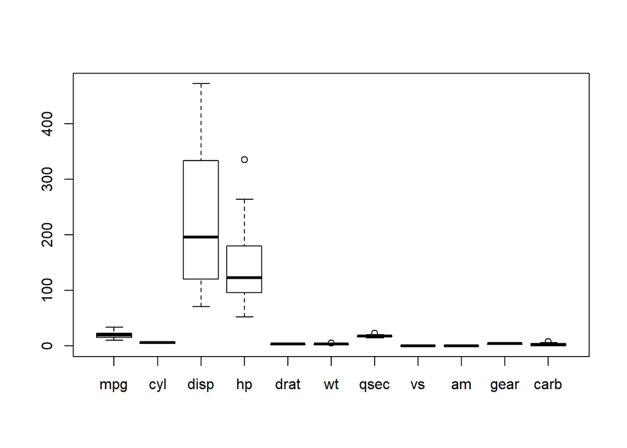

```r
  boxplot(mtcars)
```

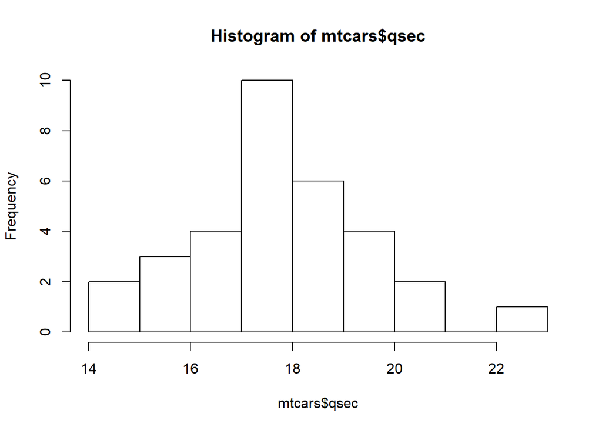

```r
  hist(mtcars$qsec)
```

Lembrando que, assim como para as funções do R em geral, os gráficos possuem várias opções de argumento, permitindo o ajuste de rótulos, cores, títulos, etc - para mais detalhes consulte o `help()` da função de interesse.

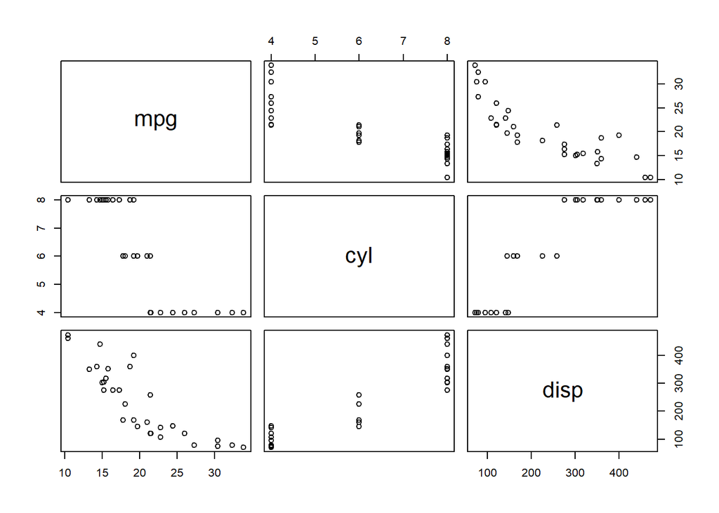

```r
#considerando as 3 primeiras colunas dos dados:
  #representação gráfica
    plot(mtcars[,1:3])
```

```r
  #representação numérica
    cor(mtcars[,1:3])
  #>             mpg        cyl       disp
  #> mpg   1.0000000 -0.8521620 -0.8475514
  #> cyl  -0.8521620  1.0000000  0.9020329
  #> disp -0.8475514  0.9020329  1.0000000
```

No R é possível evoluir de análises descritivas para inferências de forma relativamente simples. Podemos, por exemplo, aplicar testes estatísticos (e.g. `t.test()`), modelos de regressão/supervised models (`lm()`), análises de cluster/unsupervised (`kmeans()`) entre outras. Contudo, tendo sempre em mente que tais técnicas possuem diferentes opções de parâmetros, além de premissas metodológicas que, caso não respeitadas, podem nos levar a conclusões equivocadas.

Outro aspecto importante de uma análise diz respeito a transformações que podemos ter o interesse em fazer, como reordenar uma coluna, ou substituir algum elemento. No caso das bases *built-in* não temos o poder de fazer tais alterações, sendo assim podemos salvar uma base paralela para tais alterações - não alterar os dados originais é uma prática recomendada na análise de dados:

```r
dados_mtcars <- mtcars

#arredondando os dados para uma casa decimal
  dados_mtcars$qsec <- round(dados_mtcars$qsec,1)
#substituindo os valores pela descrição que consta no `?mtcars` da variável
  dados_mtcars$vs <- factor(dados_mtcars$vs, labels = c("V","S"))

#assim
  str(dados_mtcars)
  #> 'data.frame':  32 obs. of  11 variables:
  #>  $ mpg : num  21 21 22.8 21.4 18.7 18.1 14.3 24.4 22.8 19.2 ...
  #>  $ cyl : num  6 6 4 6 8 6 8 4 4 6 ...
  #>  $ disp: num  160 160 108 258 360 ...
  #>  $ hp  : num  110 110 93 110 175 105 245 62 95 123 ...
  #>  $ drat: num  3.9 3.9 3.85 3.08 3.15 2.76 3.21 3.69 3.92 3.92 ...
  #>  $ wt  : num  2.62 2.88 2.32 3.21 3.44 ...
  #>  $ qsec: num  16.5 17 18.6 19.4 17 20.2 15.8 20 22.9 18.3 ...
  #>  $ vs  : Factor w/ 2 levels "V","S": 1 1 2 2 1 2 1 2 2 2 ...
  #>  $ am  : num  1 1 1 0 0 0 0 0 0 0 ...
  #>  $ gear: num  4 4 4 3 3 3 3 4 4 4 ...
  #>  $ carb: num  4 4 1 1 2 1 4 2 2 4 ...
```

> Para consultar as bases de dados disponibilizadas por default pelo R, e pelas bibliotecas carregadas na sessão corrente: `data()`. Para consultar as princípais funções estatísticas/machile learning disponíveis por default: `library(help = "stats")`.

### 3.5.2 Importação/Exportação

Visando facilitar a dinâmica, vamos primeiro exportar a base de dados criada no último capítulo `dados_mtcars`, e então vamos importar esta mesma base de dados novamente. Para exportar os dados precisamos especificar o nome e a extensão que o arquivo será salvo, por exemplo:

```r
write.table(dados_mtcars, file = "dados_mtcars.txt")
```

Uma pergunta natural seria: onde o arquivo foi salvo? É a resposta é: no diretório de trabalho. Para saber qual o diretório de trabalho corrente, utilizamos o comando `getwd()` (*get working directory*), o que retornará algo como `"C:/Users/Documents"`. Enquanto que para alterar o diretório de trabalho temos a função `setwd()` (*set working directory*), por meio de comandos como `setwd("C:/Users/Desktop")`.

Alternativamente podemos especificar o destino do arquivo de interesse, de modo independente do diretório de trabalho, precedendo o nome do arquivo com o diretório desejado, considerando o caso assim p.e.: `write.table(dados_mtcars, file = "C:/Users/dados_mtcars.txt")` - note que trabalhamos com barras simples (`/` ou `\\`) para especificação de diretórios.

Para a leitura de dados seguimos o mesmo padrão, assim:

```r
  dados_lidos <- read.table("dados_mtcars.txt")
  str(dados_lidos)
  #> 'data.frame':  32 obs. of  11 variables:
  #>  $ mpg : num  21 21 22.8 21.4 18.7 18.1 14.3 24.4 22.8 19.2 ...
  #>  $ cyl : int  6 6 4 6 8 6 8 4 4 6 ...
  #>  $ disp: num  160 160 108 258 360 ...
  #>  $ hp  : int  110 110 93 110 175 105 245 62 95 123 ...
  #>  $ drat: num  3.9 3.9 3.85 3.08 3.15 2.76 3.21 3.69 3.92 3.92 ...
  #>  $ wt  : num  2.62 2.88 2.32 3.21 3.44 ...
  #>  $ qsec: num  16.5 17 18.6 19.4 17 20.2 15.8 20 22.9 18.3 ...
  #>  $ vs  : Factor w/ 2 levels "S","V": 2 2 1 1 2 1 2 1 1 1 ...
  #>  $ am  : int  1 1 1 0 0 0 0 0 0 0 ...
  #>  $ gear: int  4 4 4 3 3 3 3 4 4 4 ...
  #>  $ carb: int  4 4 1 1 2 1 4 2 2 4 ...
```

Tanto a função `write.table()` quanto a `read.table()`possuem uma série de parâmetros, permitindo especificações de separadores, títulos e comentários, e variações, permitindo trabalharmos com outras extensões.

> para consultar funções relacionadas pesquise os tópicos `??read` e `??write`.

## 3.6 Estruturas de controle

No que se refere as estruturas de controle - blocos de programação que, baseado em parâmetros pré-definidos, define a direção a seguir - o R possui todas as funções usualmente existentes em outras linguagens de programação. Contudo, para otimizar o trabalho com tais ferramentas, vamos primeiro listar os principais operadores lógicos disponíveis no R:

```r
#retorna TRUE (T) ou FALSE (F) se:
  !x #não
  x | y #ou: retornando T/F para cada elemento das comparações
  x || y #ou, retornando apenas um T/F (1ª comparação à esquerda do vetor)
  x & y #e, retornando T/F para cada elemento das comparações
  x && y #e, retornando apenas um T/F (1ª comparação à esquerda do vetor)
  x %in% y #se os elementos à esquerda, um a um, estão contidos à direita
```

Adicionalmente, no caso de termos vetores lógicos, as funções `any()` e `all()`, ou ainda a função `identical()` são consideravelmente úteis - função esta que precisa ser analisada com cuidado, visto trabalhar de forma bem restrita, retornando `FALSE` para diferenças sutís, como por exemplo: `identical(1,1L)`.

Voltando as estruturas de controle, considerando fluxos condicionais e de repetição, temos:

- **if** - se a declaração testada for verdade, ou seja, retornar `TRUE`, então os comandos especificados dentro das chaves `{}` serão executados:

```r
x <- 1
  if(x != 0){
    print(x+1)
  }
  #> [1] 2
```

- **if-else** - similar ao comando `if()` porém seguido de um segundo bloco, que será avaliado se, e somente se, o resultado do primeiro bloco for `FALSE`:

```r
x <- 30
  if (x<=10) {
    print("x é menor ou igual a 10")
  } else if (x>10 & x<20) {
    print("x está entre 10 e 20")
  } else{
    print("x é maior ou igual a 20")
  }
  #> [1] "x é maior ou igual a 20"
```

Existe também uma versão mais simples, em que especificamos a ação a ser tomada se a condicional especificada falsa `ifelse(condição, "se TRUE", "se FALSE")`.

- **for** - uma sequência de instruções que são repetidas com cada um dos elementos especificados:

```r
#exemplo
  x <- 1:3
  for(i in x){
    print(i)
  }
  #> [1] 1
  #> [1] 2
  #> [1] 3
```

Podemos trabalhar sem as chaves caso as instruções sejam dadas em até uma linha após o comando `for`:

```r
#exemplo
  x <- 1:3
  for(i in x) print(i)
  #> [1] 1
  #> [1] 2
  #> [1] 3
```

- **nested loops** - De modo similar ao anterior temos o caso dos loops aninhados:

```r
#exemplo ~ podemos utilizar a função `seq` para acessar os indíces de interesse
  x <- 1:2; y <- c(1,10)
  for(i in seq(x)){
    for(j in seq(y)) print(x[i]*y[j])
  }
  #> [1] 1
  #> [1] 10
  #> [1] 2
  #> [1] 20
```

- **while** - repetição de um bloco de comandos até que certa condição não seja mais satisfeita:

```r
#exemplo
  i <- 1
  while (i<=6){
    print(i*i)
    i = i+1
  }
  #> [1] 1
  #> [1] 4
  #> [1] 9
  #> [1] 16
  #> [1] 25
  #> [1] 36
```

além dos comandos citados, funções como `break()`, que pode ser utilizado para interromper um loop e dar continuidade ao fluxo do programa, ou `next()`, que descontinua uma interação particular, e pula para a próxima, também existem no R. Além do `repeat()`, um loop que executa um bloco de comandos repetidamente, até que o mesmo seja quebrado.

## 3.7 Criando funções

No R podemos criar as nossas próprias funções, por meio do objeto `function()`. Tal prática é interessante pois permite a automação de atividades de uma forma melhor estruturada e mais consistente do que a prática “copia e cola”, além de tornar o código mais legível, escalonável e reprodutível. Para criar tais funções existem três aspectos que devemos considerar: o nome do objeto criado para a função ser armazenada (que terá papel fundamental na legibilidade do código), os argumentos que a função pode, ou não, possuir, e o corpo da função, onde é definido o que a função faz, e o que retorna:

```r
#modelo
  nome_funcao <- function(arg_1, arg_2, ...){
     corpo da função
  }
```

Em relação ao retorno da função, o R, por default, retorna a última linha do corpo da função. Porém, alternativamente, podemos utilizar a função `return()`, que garante o retorno independente da posição em relação aos demais itens do corpo da função.

Um aspecto importante de ser considerado no contexto das funções são os seus ambientes, uma vez que estas possuem seu próprio `environment`, ou seja, sua própria coleção de objetos (funções, variáveis, etc). De modo que nem os cálculos realizados dentro de uma função não alteram, e não são registrados, pelos demais ambientes. Contudo, o `environment` de uma função consegue consultar o ambiente em que foi definida (`parent environment`), bem como o ambiente pai deste, e assim por diante, de forma hierárquica. Tal recurso é utilizado no contexto em que algum objeto necessário para a execução da função não é encontrado. Como exemplo vamos analisar a função `celcius_fahrenheit` definida abaixo, em que para a temperatura em celsius `temp_c` a respectiva temperatura em fahrenheit `temp_f` é calculada, porém o resultado só retornado quando chamamos a função `celcius_fahrenheit()`, e não para o objeto `temp_f`:

```r
#exemplo
  temp_c <- 25

  celcius_fahrenheit <- function(){
    temp_f <- (temp_c * 9/5) + 32
    temp_f #ou, equivalentemente, return(temp_f)
  }

  temp_f
  #> Error in eval(expr, envir, enclos): objeto 'temp_f' não encontrado
  celcius_fahrenheit()
  #> [1] 77
  temp_f
  #> Error in eval(expr, envir, enclos): objeto 'temp_f' não encontrado
```

Revisitando os pontos anteriormente comentados, temos que : - como a função não encontrou o objeto `temp_c` em seu `environment`, passou a procura-la no ambiente em que a função foi definida, no caso, o `Global Environment`, onde encontrou o objeto `temp_c` com o valor `25`; - apesar da função conseguir acessar o ambiente em que foi criada, ela não tem o poder de gravar objetos fora do seu próprio `environment`. Sendo assim o objeto `temp_f` só “existe” dentro da funçao, e ao ser chamado fora desta não é encontrado; e - a função ao ser chamada no `Global Environment` retorna a sua última linha, no caso o resultado do objeto `temp_f` - mas não o objeto em si.

O exemplo acima foi desenhado visando ilustrar como o R lida com os diferentes ambientes, porém, em termos práticos é extremamente desaconselhável deixar que a função dependa de parâmetros externos ao seu próprio `environment`. Como prática aconselhável, todas as dependências devem ser especificadas e passadas como argumentos da função, assim:

```r
celcius_fahrenheit <- function(temp_c){
    temp_f <- (temp_c * 9/5) + 32
    temp_f
}

temp_c <- 25
celcius_fahrenheit()
  #> Error in celcius_fahrenheit(): argumento "temp_c" ausente, sem padrão
celcius_fahrenheit(temp_c)
  #> [1] 77

#ou o que faremos mais recorrentemente
temp_f <- celcius_fahrenheit(temp_c)
```

Ainda no contexto da relação de funções e seus ambientes, temos os operadores `<<-` e `->>` como ferramentas úteis para trabalhar com a definição de objetos em mais de um nível. De modo que primeiro o valor do objeto será procurado na cadeia de ambientes pais, e se essa variável for encontrada (e sua ligação não estiver bloqueada), seu valor será redefinido, caso contrário, a atribuição ocorrerá no ambiente global. Assim:

```r
#exemplo
  x <- 0

  myfun <- function(){
      x <<- 1
      y <<- 1
      z <- 1
      return (x+y+z)
  }
#tendo como saída:
  myfun()
  #> [1] 3
#enquanto que os objetos:
  x #foi redefinida
  #> [1] 1
  y #possou a constar no ambiente global
  #> [1] 1
  z #não existe globalmente
  #> Error in eval(expr, envir, enclos): objeto 'z' não encontrado
```

Em relação aos argumentos, assim como ocorre nas funções *built-in*, podemos especificar valores default para os parâmetros, bem como definir o corpo da função em uma mesma linha sem o uso de chaves, como descrito para o `for()`:

```r
  ex_function <- function(x, y=1) x+y
  ex_function(1,0)
  #> [1] 1
  ex_function(1)
  #> [1] 2
```

Adicionalmente podemos utilizar recursos como `break()` ou `cat()` (uma versão um pouco menos generica da função `print()`), permitindo, por exemplo:

```r
celcius_fahrenheit <- function(temp_c){
    temp_f <- (temp_c * 9/5) + 32

    if(temp_c>10){
      cat("\n Por que 10? Porque sim! \n")
      stop
      }

    temp_f
}

celcius_fahrenheit(25)
  #>
  #>  Por que 10? Porque sim!
  #> [1] 77
```

> Ao definir funções, podemos salva-las em outros scripts e chama-las por meio da função `source()`, sendo necessário especificar apenas o nome do script (juntamente com o diretório caso não se encontre no mesmo diretório).

## 3.8 Trabalhando com bibliotecas

Bibliotecas tratam-se de uma coleção de funções, dados e códigos compilados. A instalação destas bibliotecas, ou pacotes, como são também chamados, é simples, podendo ser feita via point-and-click (‘Tools > Install.Packages’), ou pelo comando `install.packages("nome_do_pacote")`. Após a instalação é necessário apenas carregar os pacotes desejados, por meio do comando `library(nome_do_pacote)` - sem aspas duplas, ou ainda indo diretamente na janela *Packages* do RStudio, e setando as bibliotecas que deseja carregar:

```r
#instalação do pacote `ggplot2`
  install.packages("ggplot2")

#carregando o pacote
  library(ggplot2)
```

Tais bibliotecas se encontram disponíveis pela rede de distribuição oficial do R, o CRAN (do inglês *Comprehensive R Archive Network*). Mas existem também bibliotecas disponibilizadas via outros repositórios como o Bioconductor e o GitHub, ou ainda disponíveis para download. Nestes casos é necessário fazer a instalação com `devtools::install_github("nome-do-repo/nome-do-pacote")`, após a instalação do pacote `devtools`, ou, no caso de um arquivo zipado, adicionando o parâmetro `repos = NULL`, na função `install.packages()`.

```r
#instalação do pacote a partir do CRAN
  install.packages("ggplot2")
#instalação a partir do git (versão mais recente da biblioteca)
  install.packages("ggplot2")
  devtools::install_github("tidyverse/ggplot2")
#instalação a partir de um arquivo .zip
  install.packages("C:/Users/ggplot2.zip", repos = NULL)
```

Um ponto importante é que uma vez que a biblioteca esteja instalada, não é necessário carregar toda a biblioteca para utilizar uma função especificamente, sendo suficiente utilizar o nome da biblioteca, seguido por `::` e o nome da função desejada, ou seja: `nome_da_biblioteta::função_de_interesse()`. Tal recurso é interessante visto que ao fazer o load de uma biblioteca, todas as funções desta se sobrepõem as que já estão carregadas. E como é comum que pacotes diferentes compartilhem funções com o mesmo nome, está torna-se uma forma de evitar tal problema - note que este recurso foi utilizado no caso do `devtools::install_github()` do exemplo acima.

Para checar quais bibliotecas estão instaladas podemos checar a aba `Packages` do RStudio, ou por meio do comando `installed.packages()`. Outro ponto importante são as atualizações das bibliotecas, que pode ser feita para todas as blibotecas por meio do comando `update.packages()`, ou reinstalando o pacote de interesse - para consultar quais estão desatualizadas temos `old.packages()`. Por fim, para diferenciarmos as funções *built-in* daquelas carregadas via bibliotecas, vamos chamar as primeiras de funções do `R base`.

# 4 R para Ciência de Dados

Vamos agora explorar o R do ponto de vista da Ciência de Dados, considerando um ciclo usual de *análise*, contemplando: leitura, tidy (organização), transformações, visualizações, modelagens e comunicação, e as possíveis repetições cabíveis.

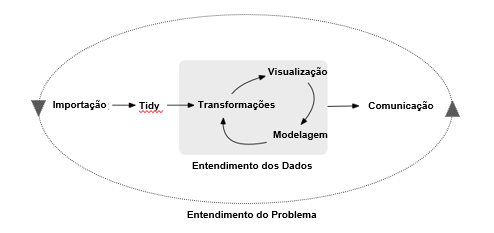

Ciclo de Análise da Ciência de Dados

Note que aspectos como deploy e manutenção de modelos não estão sendo considerados neste flow. Isto porque, apesar da incontextável importância, tais fases tendem a priorizar aspectos como integrações com sistemas, performance, e questões relacionadas, enquanto que para o ciclo pontuado acima, temos o entendimento e a modelagem do problema como meta principal.

Visando a implementação de tal ciclo no contexto da programação R iremos trabalhar com a coleção de pacotes do `tidyverse`.

## 4.1 O universo tidyverse

O `tidyverse` é um conjunto de bibliotecas que compartilham a mesma gramática, contemplando todo o ciclo de análise da ciência de dados, e tendo como base dados *tidy* - uma forma padronizada de vincular a estrutura de um conjunto de dados (seu layout físico) com sua semântica (seu significado). Para entendermos melhor tais características, vamos instalar o pacote `tidyverse` e discutir a estrutura de dados, gramática e aspectos abordados por este.

```r
install.packages("tidyverse")
```

### 4.1.1 Dados: Tidy

Conforme comentado, dados *tidy* possuem uma estrutura padronizada visando relacionar o layout dos dados com seu significado. Para tal temos que, independente da origem, características, problemas e layout dos dados, estes precisam ser organizados garantindo que:

- cada variável tenha a sua própria coluna;
- cada observação tenha a sua própria linha; e
- cada valor tenha a sua própria célula.

Apesar da simplicidade das premissas, o fato do pre-requisito existir e ser previsto no flow, garante recursos para os ajustes necessários, e coerência para todo o ecossistema de análise.

No R tal estrutura pode ser alcançada por meio dos `data.frames`, porém as bibliotecas do `tidyverse` trabalham com uma estrutura mais moderna, chamada `tbl_df` ou `tibble`. Tal estrutura é proveniente da biblioteca com o mesmo nome, porém, por ser um dos pacotes base do `tidyverse` podemos carrega-lo utilizando qualquer uma destas bibliotecas. Visando ilustrar esta nova estrutura, segue a reestruturação da base `mtcars`:

```r
#carregando a biblioteca `tibble`
  library(tibble)

  #como data.frame (estrutura original)
    class(mtcars)
  #> [1] "data.frame"
  #como tibble
    mtcars_2 <- as_tibble(mtcars)
    class(mtcars_2)
  #> [1] "tbl_df"     "tbl"        "data.frame"
  #visualização como tibble:
    mtcars_2
  #> # A tibble: 32 x 11
  #>      mpg   cyl  disp    hp  drat    wt  qsec    vs    am  gear  carb
  #>    <dbl> <dbl> <dbl> <dbl> <dbl> <dbl> <dbl> <dbl> <dbl> <dbl> <dbl>
  #>  1  21       6  160    110  3.9   2.62  16.5     0     1     4     4
  #>  2  21       6  160    110  3.9   2.88  17.0     0     1     4     4
  #>  3  22.8     4  108     93  3.85  2.32  18.6     1     1     4     1
  #>  4  21.4     6  258    110  3.08  3.22  19.4     1     0     3     1
  #>  5  18.7     8  360    175  3.15  3.44  17.0     0     0     3     2
  #>  6  18.1     6  225    105  2.76  3.46  20.2     1     0     3     1
  #>  7  14.3     8  360    245  3.21  3.57  15.8     0     0     3     4
  #>  8  24.4     4  147.    62  3.69  3.19  20       1     0     4     2
  #>  9  22.8     4  141.    95  3.92  3.15  22.9     1     0     4     2
  #> 10  19.2     6  168.   123  3.92  3.44  18.3     1     0     4     4
  #> # ... with 22 more rows
```

Note que a visualização que temos ao chamar os dados no formato `tibble` é muito mais simples e descritiva que a visualização original (que pode ser consultada na seção Análises Descritivas). Adicionalmente questões como performance e consistência também apresentam melhorias frente aos `data.frames`. Para criar tais estruturas podemos:

```r
#função tibble: construir a partir de colunas
  tibble(x = 1:3, y = c("a", "b", "c"))
  #> # A tibble: 3 x 2
  #>       x y
  #>   <int> <chr>
  #> 1     1 a
  #> 2     2 b
  #> 3     3 c

#função tribble: ou a partir de linhas
  tribble(~ x, ~ y,
           1, "a",
           2, "b",
           3, "c")
  #> # A tibble: 3 x 2
  #>       x y
  #>   <dbl> <chr>
  #> 1     1 a
  #> 2     2 b
  #> 3     3 c
```

### 4.1.2 Gramática: Pipe

Em relação a gramática o `tidyverse` permite que trabalhemos com a sintaxe utilizada até então, em que a leitura de uma sequência de operações aplicadas a um objeto é feita de dentro para fora, isto é:

```r
#leitura de dentro para fora
  funçãoN(...(função2(função1(dados))))
```

Contudo os pacotes do `tidyverse` oferecem recursos que são melhor aproveitados quando aplicamos operações em sequência, por meio do operador pipe `%>%`:

```r
#leitura em sequência
  dados %>%
    função1() %>%
    função2() %>%
    ...
    funçãoN()
```

Assim, por exemplo, teremos:

```r
#exemplo
  x <- 1:5

  #leitura de dentro para fora
  floor(sqrt(sum(x)))
  #> [1] 3

  #leitura sequencial
  x %>%
    sum %>%
    sqrt %>%
    floor
  #> [1] 3
```

O que além do claro ganho em termos de leitura, passamos a ter uma análise modular, de modo que podemos alterar, remover ou inserir tais módulos de forma simples, sem comprometer o todo:

```r
#ilustrando a facilidade em excluir uma função
  x %>%
    #sum %>%
    sqrt %>%
    floor
  #> [1] 1 1 1 2 2
```

O operador `%>%` foi originalmente introduzido no R por meio da biblioteca `magrittr`, porém ganhou tamanha importância que passou a ser contemplado por diversos pacotes, inclusive, claro, o `tidyverse`.

```r
library(tidyverse)
```

> O operador `%>%` pode ser chamado por meio do atalho `'ctrl + shift + M'` no RStudio.

### 4.1.3 O Workflow de análise

Por fim temos a questão dos pilares do workflow de análise, apresentado no início deste capítulo, e para exemplificar como o tidyverse conversa com este flow, segue a descrição das bibliotecas que são instaladas e carregadas ao instalarmos e carregarmos o `tidyverse`:

- **readr**: leitura dos dados
- **tibble**: opção ao data frame, otimizada
- **tidyr**: reformulação de layout dos dados
- **dplyr**: manipulação de dados
- **ggplot2**: criação de gráficos
- **purrr**: programação funcional
- **forcats**: operações com variáveis categoricas
- **stringr**: operações com strings

Adicionalmente, temos que algumas bibliotecas, apesar de não serem carregadas juntamente com os pacotes listados acima, são instaladas, estando à disposição para uso:

- **readxl**: leitura e escrita de arquivos .xls e .xlsx
- **haven**: leitura e escrita de arquivos SPSS, Stata, e SAS
- **lubridate**: operações para trabalhar com datas
- **broom**: resume informações de modelagem de forma estruturada
- **knitr**: relatórios dinâmicos

Lembrando que para utilizar as funções de tais bibliotecas é necessário carregar o pacote individualmente. Ou, alternativamente, chamando a função de interesse especificamente, por meio de comandos como: `readxl::read_xlsx()` ou `lubridate::dmilliseconds()`.

Somando todas estas bibliotecas ao `Rmarkdown`, recurso que permite a execução de códigos e relatórios automaticamente. Diminuindo significantemente o gap existente entre a análise e a preparação do material a ser compartilhado com os resultados obtidos/documentação. O workflow de análise passa a ser:

[figure not shown]

Ciclo de Análise da Ciência de Dados por Tidyverse

> Para consultar as funções disponíveis nas principais bibliotecas do `tidyverse` acesse as folhas de consultas (*cheat sheets*), disponíveis no site oficial do RStudio.

Com todos estes pontos postos, iremos agora discutir cada um dos pilares do ciclo de análise da Ciência de Dados.

## 4.2 Importação

A etapa de importação de dados pode significar ler dados armazenados em: arquivos de diferentes extensões, dados provenientes de outras ferramentas, APIs da Web, e etc. Para o primeiro caso, como alternativa ao `read.table()` do `R base`, temos a versão `readr` do `tidyverse`. Nesta a leitura é mais rápida, com argumentos padronizados, e retornam `tibbles` ao invés de `data frames`. Seguem alguns exemplos para a leitura de um arquivo `"file"`, presente no diretório corrente de trabalho, considerando diferentes opções de extensões e delimitadores:

- `read_csv("file.csv")` - lê arquivos delimitados por vírgula
- `read_csv2("file.csv")` - lê arquivos delimitados por ponto e vírgula
- `read_delim("file.txt", delim="|")` - lê arquivos delimitados por tabulação (exemplo dado para o delimitador `|`)
- `read_fwf("file.fwf", col_positions = c(1,3,5))` - lê arquivos com largura fixa (exemplo dado para o padrão `1,3,5`)

Em todos os casos é possível especificar características como: nome das colunas, cabeçalho, linhas para serem puladas, ou ainda a pré-especificação da classe de cada uma das colunas do arquivo. Contudo, no caso deste último parâmetro não ser listado, as funções do `readr` irão “adivinhar” a classe das colunas, retornando uma mensagem com tais informações, conforme exemplo abaixo:

```r
read_csv(readr_example("mtcars.csv"))
  #> Parsed with column specification:
  #> cols(
  #>   mpg = col_double(),
  #>   cyl = col_double(),
  #>   disp = col_double(),
  #>   hp = col_double(),
  #>   drat = col_double(),
  #>   wt = col_double(),
  #>   qsec = col_double(),
  #>   vs = col_double(),
  #>   am = col_double(),
  #>   gear = col_double(),
  #>   carb = col_double()
  #> )
  #> # A tibble: 32 x 11
  #>      mpg   cyl  disp    hp  drat    wt  qsec    vs    am  gear  carb
  #>    <dbl> <dbl> <dbl> <dbl> <dbl> <dbl> <dbl> <dbl> <dbl> <dbl> <dbl>
  #>  1  21       6  160    110  3.9   2.62  16.5     0     1     4     4
  #>  2  21       6  160    110  3.9   2.88  17.0     0     1     4     4
  #>  3  22.8     4  108     93  3.85  2.32  18.6     1     1     4     1
  #>  4  21.4     6  258    110  3.08  3.22  19.4     1     0     3     1
  #>  5  18.7     8  360    175  3.15  3.44  17.0     0     0     3     2
  #>  6  18.1     6  225    105  2.76  3.46  20.2     1     0     3     1
  #>  7  14.3     8  360    245  3.21  3.57  15.8     0     0     3     4
  #>  8  24.4     4  147.    62  3.69  3.19  20       1     0     4     2
  #>  9  22.8     4  141.    95  3.92  3.15  22.9     1     0     4     2
  #> 10  19.2     6  168.   123  3.92  3.44  18.3     1     0     4     4
  #> # ... with 22 more rows
```

Adicionalmente temos opções como os pacotes `readxl` e `haven`, anteriormente citadas, o R dispõe de recursos como: `DBI`, `jsonlite`, `xml2`, `httr` ou o `sparklyr`, esta última será melhor detalhada na seção referente à Big Data.

### 4.2.1 Diretórios e Projetos

Conforme apresentado anteriormente, para importar/exportar arquivos que não se encontram no diretório de trabalho corrente, podemos especificar o diretório em que o arquivo se encontra (`"diretorio/arquivo.ext"`), ou mudar o diretório de trabalho em si (`setdw()`). Existe ainda uma terceira alternativa: trabalhar com a opção de projetos do RStudio (`.RProj`). Nesta, o diretório em que o arquivo `.RProj` estiver salvo, passa a ser a pasta raiz de todas as análises. Assim todas as especificações dos arquivos de input/output, scripts, e etc, podem ser setados sem a necessidade de detalhar a localização exata do diretório. Tal prática, bem como a adoção de estruturas para a organização dos arquivos, facilitam a evolução e o compartilhamento do trabalho. Para criar um projeto no RStudio, é necessário clicar no ícone superior à direita, conforme a imagem abaixo:

[figure not shown]

RStudio: Projeto

Posteriormente, para abrir o projeto, podemos ir no mesmo ícone, no `File/Open Project` ou ainda dando duplo click no arquivo `.Rproj`.

## 4.3 Tidy

Após a importação dos dados, passamos para a etapa de tidy dos dados, também chamada de *tidying data*. Para isto iremos primeiramente visualizar os dados, no R existem várias funções *built-in* para isto, como a função `names()`, que retorna o nome das colunas, ou `str()`, que permite a visualização da estrutura de um objeto arbitrário.

Todas as funções citadas serão igualmente úteis e utilizadas no contexto do `tidyverse`, mas, com o pacote `dplyr`, passamos a ter também a opção `glimpse()`. Nesta, de modo similar ao `str()`, temos o número de observações (linhas) e variáveis (colunas) dos dados, porém com a quantidade de observações ajustadas ao display do Console.

```r
#exemplo: função `glimpse` para visualização
  mtcars %>% glimpse()
  #> Observations: 32
  #> Variables: 11
  #> $ mpg  <dbl> 21.0, 21.0, 22.8, 21.4, 18.7, 18.1, 14.3, 24.4, 22.8, 19....
  #> $ cyl  <dbl> 6, 6, 4, 6, 8, 6, 8, 4, 4, 6, 6, 8, 8, 8, 8, 8, 8, 4, 4, ...
  #> $ disp <dbl> 160.0, 160.0, 108.0, 258.0, 360.0, 225.0, 360.0, 146.7, 1...
  #> $ hp   <dbl> 110, 110, 93, 110, 175, 105, 245, 62, 95, 123, 123, 180, ...
  #> $ drat <dbl> 3.90, 3.90, 3.85, 3.08, 3.15, 2.76, 3.21, 3.69, 3.92, 3.9...
  #> $ wt   <dbl> 2.620, 2.875, 2.320, 3.215, 3.440, 3.460, 3.570, 3.190, 3...
  #> $ qsec <dbl> 16.46, 17.02, 18.61, 19.44, 17.02, 20.22, 15.84, 20.00, 2...
  #> $ vs   <dbl> 0, 0, 1, 1, 0, 1, 0, 1, 1, 1, 1, 0, 0, 0, 0, 0, 0, 1, 1, ...
  #> $ am   <dbl> 1, 1, 1, 0, 0, 0, 0, 0, 0, 0, 0, 0, 0, 0, 0, 0, 0, 1, 1, ...
  #> $ gear <dbl> 4, 4, 4, 3, 3, 3, 3, 4, 4, 4, 4, 3, 3, 3, 3, 3, 3, 4, 4, ...
  #> $ carb <dbl> 4, 4, 1, 1, 2, 1, 4, 2, 2, 4, 4, 3, 3, 3, 4, 4, 4, 1, 2, ...
```

A partir da visualização começamos a fazer os ajustes necessários para garantir que os dados estejam organizado de uma forma `tidy`, tendo como principal ferramenta a biblioteca `tidyr`. Seguem as principais funções deste pacote utilizando bases disponíveis pela própria biblioteca:

- **Redimensionamento de dados**
  - `gather()` - reorganiza os dados, combinando as colunas especificadas na coluna parâmetro `key`, e seus valores na coluna parâmetro `value`. Com tal tipo de ajuste podemos organizar os dados de modo a consultar várias colunas de interesse de uma única vez, algo útil para a aplicação de loops, funções e gráficos, conforme veremos na seção `Visualização`.

```r
#base para exemplo
  table4a
  #> # A tibble: 3 x 3
  #>   country     `1999` `2000`
  #> * <chr>        <int>  <int>
  #> 1 Afghanistan    745   2666
  #> 2 Brazil       37737  80488
  #> 3 China       212258 213766

#exemplo: passando as colunas para linhas
  table4a_new <- table4a %>%
    gather(`1999`, `2000`, key = "ano", value = "valores")

  table4a_new
  #> # A tibble: 6 x 3
  #>   country     ano   valores
  #>   <chr>       <chr>   <int>
  #> 1 Afghanistan 1999      745
  #> 2 Brazil      1999    37737
  #> 3 China       1999   212258
  #> 4 Afghanistan 2000     2666
  #> 5 Brazil      2000    80488
  #> 6 China       2000   213766
```

- `spread()` - de maneira oposta a função anterior, aqui podemos expandir linhas em colunas:

```r
#exemplo: passando linhas para colunas
  table4a_new %>%
    spread(ano, valores)
  #> # A tibble: 3 x 3
  #>   country     `1999` `2000`
  #>   <chr>        <int>  <int>
  #> 1 Afghanistan    745   2666
  #> 2 Brazil       37737  80488
  #> 3 China       212258 213766
```

- **Dividir/combinar células**
  - `separate()` - divide uma única coluna em várias colunas, similarmente a opção `separate_rows()`, que faz a mesma coisa para linhas.

```r
#base para exemplo
  table3
  #> # A tibble: 6 x 3
  #>   country      year rate
  #> * <chr>       <int> <chr>
  #> 1 Afghanistan  1999 745/19987071
  #> 2 Afghanistan  2000 2666/20595360
  #> 3 Brazil       1999 37737/172006362
  #> 4 Brazil       2000 80488/174504898
  #> 5 China        1999 212258/1272915272
  #> 6 China        2000 213766/1280428583

#exemplo: dividindo colunas
  table3 %>% separate(rate, into = c("cases","pop"))
  #> # A tibble: 6 x 4
  #>   country      year cases  pop
  #>   <chr>       <int> <chr>  <chr>
  #> 1 Afghanistan  1999 745    19987071
  #> 2 Afghanistan  2000 2666   20595360
  #> 3 Brazil       1999 37737  172006362
  #> 4 Brazil       2000 80488  174504898
  #> 5 China        1999 212258 1272915272
  #> 6 China        2000 213766 1280428583

#exemplo: dividindo linhas
  table3 %>% separate_rows(rate)
  #> # A tibble: 12 x 3
  #>    country      year rate
  #>    <chr>       <int> <chr>
  #>  1 Afghanistan  1999 745
  #>  2 Afghanistan  1999 19987071
  #>  3 Afghanistan  2000 2666
  #>  4 Afghanistan  2000 20595360
  #>  5 Brazil       1999 37737
  #>  6 Brazil       1999 172006362
  #>  7 Brazil       2000 80488
  #>  8 Brazil       2000 174504898
  #>  9 China        1999 212258
  #> 10 China        1999 1272915272
  #> 11 China        2000 213766
  #> 12 China        2000 1280428583
```

- `unite()` - e de maneira oposta as separações, temos a função que combina várias colunas.

```r
#base para exemplo
  table3_separate <- table3 %>% separate(rate, into = c("cases", "pop"))

#exemplo: separando a coluna rate em duas
  table3_separate %>%
    unite(cases, pop, col = "rate", sep = "/")
  #> # A tibble: 6 x 3
  #>   country      year rate
  #>   <chr>       <int> <chr>
  #> 1 Afghanistan  1999 745/19987071
  #> 2 Afghanistan  2000 2666/20595360
  #> 3 Brazil       1999 37737/172006362
  #> 4 Brazil       2000 80488/174504898
  #> 5 China        1999 212258/1272915272
  #> 6 China        2000 213766/1280428583
```

- **Dados Faltantes**
  - `drop_na()` - excluí todas as linhas que apresentam elementos faltantes.
  - `fill()` - substituí os dados faltantes pelo valor mais recente da referida coluna.
  - `replace_na()` - substituí os dados faltantes por um valor pré especificado.

```r
#base para exemplo
  airquality[1:5,]
  #>   Ozone Solar.R Wind Temp Month Day
  #> 1    41     190  7.4   67     5   1
  #> 2    36     118  8.0   72     5   2
  #> 3    12     149 12.6   74     5   3
  #> 4    18     313 11.5   62     5   4
  #> 5    NA      NA 14.3   56     5   5

#exemplo: exclusão das linhas identificadas com NA
  airquality[1:5,] %>% drop_na()
  #>   Ozone Solar.R Wind Temp Month Day
  #> 1    41     190  7.4   67     5   1
  #> 2    36     118  8.0   72     5   2
  #> 3    12     149 12.6   74     5   3
  #> 4    18     313 11.5   62     5   4
  airquality[1:5,] %>% fill(c(Ozone, Solar.R))
  #>   Ozone Solar.R Wind Temp Month Day
  #> 1    41     190  7.4   67     5   1
  #> 2    36     118  8.0   72     5   2
  #> 3    12     149 12.6   74     5   3
  #> 4    18     313 11.5   62     5   4
  #> 5    18     313 14.3   56     5   5
  airquality[1:5,] %>% replace_na(list(Ozone=0, Solar.R=0))
  #>   Ozone Solar.R Wind Temp Month Day
  #> 1    41     190  7.4   67     5   1
  #> 2    36     118  8.0   72     5   2
  #> 3    12     149 12.6   74     5   3
  #> 4    18     313 11.5   62     5   4
  #> 5     0       0 14.3   56     5   5
```

> Uma função particularmente interessante é o `View()`, pertencente ao R Base, que exibe os dados em uma nova janela, permitindo recursos como filtros e ordenação, via point-and-click.

## 4.4 Manipulação

A próxima etapa no processo de análise é a manipulação da base visando desde o entendimento de suas variáveis, considerando tabulações e estatísticas, até a criação de novas variáveis. Para tal trabalharemos com o pacote `dplyr`, com recursos para:

- **Manipulação de variáveis**
  - `select()` - seleciona variáveis, permitindo o uso de recursos como:
    - `starts_with()`, `matches()`, `num_range()`, ou `everything()`
  - `mutate()` - cria/modifica variáveis
  - `rename()` - renomeia variáveis

```r
#base exemplo
  iris[1:5,] %>% as_tibble()
  #> # A tibble: 5 x 5
  #>   Sepal.Length Sepal.Width Petal.Length Petal.Width Species
  #>          <dbl>       <dbl>        <dbl>       <dbl> <fct>
  #> 1          5.1         3.5          1.4         0.2 setosa
  #> 2          4.9         3            1.4         0.2 setosa
  #> 3          4.7         3.2          1.3         0.2 setosa
  #> 4          4.6         3.1          1.5         0.2 setosa
  #> 5          5           3.6          1.4         0.2 setosa

#exemplo: seleção, mudança de nome, e definição de uma nova variável
  iris[1:5,] %>%
    as_tibble() %>%
    select(Sepal.Length) %>%
    rename(variavel_original = Sepal.Length) %>%
    mutate(variavel_original_normalizada =  variavel_original %>% scale)
  #> # A tibble: 5 x 2
  #>   variavel_original variavel_original_normalizada[,1]
  #>               <dbl>                             <dbl>
  #> 1               5.1                             1.16
  #> 2               4.9                             0.193
  #> 3               4.7                            -0.772
  #> 4               4.6                            -1.25
  #> 5               5                               0.675
```

- **Sumarizações**
  - `group_by()` - manipula a base de dados segmentando por cada “grupo” da variável especificada e, posteriormente, combina os resultados, considerando os comandos seguintes dados.
  - `summarise()` - calcula resumos de uma tabela conforme especificação

```r
#exemplo: calculo da quantidade de observações de cada categoria, e
# média para a variável Petal.Length considerando a visão por Species
  iris %>%
    group_by(Species) %>%
    summarise(N = n(),
              PetalLength_media = mean(Petal.Length))
  #> # A tibble: 3 x 3
  #>   Species        N PetalLength_media
  #>   <fct>      <int>             <dbl>
  #> 1 setosa        50              1.46
  #> 2 versicolor    50              4.26
  #> 3 virginica     50              5.55
```

- **Manipulação de casos**
  - `filter()` - filtra linhas da base de dados a partir de critérios lógicos (retorno `TRUE`/`FALSE`)
  - `slice()` - seleciona linhas por suas posições ordinais
  - `top_n()` - ordena as primeiras `n` observações das colunas listadas
  - `arrange()` - ordena as linhas de acordo com as colunas especificadas
  - `distinct()` - remove as linhas duplicadas de uma dada entrada

```r
#exemplo: seleção segundo padrão de nomenclatura + filtro e ordenação
  iris %>%
    select(starts_with("Petal")) %>%
    filter(Petal.Length > 6, Petal.Width > 2) %>%
    arrange(Petal.Width)
  #>   Petal.Length Petal.Width
  #> 1          6.6         2.1
  #> 2          6.7         2.2
  #> 3          6.9         2.3
  #> 4          6.1         2.3
  #> 5          6.1         2.5

#exemplo: valor máximo de Sepal.Length para cada specie
  iris %>%
    group_by(Species) %>%
    top_n(1, Sepal.Length)
  #> # A tibble: 3 x 5
  #> # Groups:   Species [3]
  #>   Sepal.Length Sepal.Width Petal.Length Petal.Width Species
  #>          <dbl>       <dbl>        <dbl>       <dbl> <fct>
  #> 1          5.8         4            1.2         0.2 setosa
  #> 2          7           3.2          4.7         1.4 versicolor
  #> 3          7.9         3.8          6.4         2   virginica
```

- **Amostra**
  - `sample_n()` - seleciona uma amostra aleatória considerando o número de elementos especificado
  - `sample_frac()` - seleciona uma amostra aleatória considerando a proporção especificada

```r
#exemplo: amostra considerando o número de observações desejado
# seguido de uma amostra considerando proporção
  iris %>%
    sample_n(10) %>%
    sample_frac(0.5)
  #>   Sepal.Length Sepal.Width Petal.Length Petal.Width    Species
  #> 1          5.0         3.3          1.4         0.2     setosa
  #> 2          5.0         3.2          1.2         0.2     setosa
  #> 3          4.8         3.0          1.4         0.1     setosa
  #> 4          6.7         3.3          5.7         2.5  virginica
  #> 5          6.3         2.5          4.9         1.5 versicolor
```

- **Combinando Bases**
  - `inner_join()` - retorna todas as linhas da base à esquerda que possuem valores correspondentes na base à direita. Se houver várias correspondências entre xe y, todas as combinações das correspondências serão retornadas.
  - `left_join()` - retorna todas as linhas de x e todas as colunas de x e y. Linhas em x sem correspondência em y terão valores de NA nas novas colunas. Se houver várias correspondências entre x e y, todas as combinações das correspondências serão retornadas.
  - `full_join()` - retorna todas as linhas e todas as colunas de xe y. Onde não há valores correspondentes, retorna NA para o ausente.

```r
#bases para exemplo
  band_members %>% glimpse()
  #> Observations: 3
  #> Variables: 2
  #> $ name <chr> "Mick", "John", "Paul"
  #> $ band <chr> "Stones", "Beatles", "Beatles"
  band_instruments %>% glimpse()
  #> Observations: 3
  #> Variables: 2
  #> $ name  <chr> "John", "Paul", "Keith"
  #> $ plays <chr> "guitar", "bass", "guitar"
  band_instruments2 %>% glimpse()
  #> Observations: 3
  #> Variables: 2
  #> $ artist <chr> "John", "Paul", "Keith"
  #> $ plays  <chr> "guitar", "bass", "guitar"

#exemplo: em que as variáveis para join possuem nomes iguais
  left_join(band_members, band_instruments) %>% glimpse()
  #> Joining, by = "name"
  #> Observations: 3
  #> Variables: 3
  #> $ name  <chr> "Mick", "John", "Paul"
  #> $ band  <chr> "Stones", "Beatles", "Beatles"
  #> $ plays <chr> NA, "guitar", "bass"

#exemplo: em que as variáveis para join possuem nomes diferentes
  left_join(band_members, band_instruments2, by = c("name"="artist")) %>%
    glimpse()
  #> Observations: 3
  #> Variables: 3
  #> $ name  <chr> "Mick", "John", "Paul"
  #> $ band  <chr> "Stones", "Beatles", "Beatles"
  #> $ plays <chr> NA, "guitar", "bass"
```

Conforme já comentado, existem bibliotecas para trabalharmos com diferentes classes de dados. Vamos citar algumas funcionalidades dos três pacotes com tal finalidade contidos no `tidyverse`:

- **fatores**
  - `fct_count()` - conta o número de valores de cada nível
  - `fct_relevel()` - reordenar os níveis dos fatores
  - `fct_explicit_na()` - adicionar o `NA` como um dos níveis

```r
#base para exemplo
  gss_cat %>% glimpse
  #> Observations: 21,483
  #> Variables: 9
  #> $ year    <int> 2000, 2000, 2000, 2000, 2000, 2000, 2000, 2000, 2000, ...
  #> $ marital <fct> Never married, Divorced, Widowed, Never married, Divor...
  #> $ age     <int> 26, 48, 67, 39, 25, 25, 36, 44, 44, 47, 53, 52, 52, 51...
  #> $ race    <fct> White, White, White, White, White, White, White, White...
  #> $ rincome <fct> $8000 to 9999, $8000 to 9999, Not applicable, Not appl...
  #> $ partyid <fct> "Ind,near rep", "Not str republican", "Independent", "...
  #> $ relig   <fct> Protestant, Protestant, Protestant, Orthodox-christian...
  #> $ denom   <fct> Southern baptist, Baptist-dk which, No denomination, N...
  #> $ tvhours <int> 12, NA, 2, 4, 1, NA, 3, NA, 0, 3, 2, NA, 1, NA, 1, 7, ...

#exemplo: contabilizando a quantidade de religiões declaradas
  gss_cat$race %>%
  fct_count()
  #> # A tibble: 4 x 2
  #>   f                  n
  #>   <fct>          <int>
  #> 1 Other           1959
  #> 2 Black           3129
  #> 3 White          16395
  #> 4 Not applicable     0
```

- **strings**
  - `str_detect()` - identificar a presença de padrões em uma string
  - `str_count()` - contabiliza o número de vezes que um padrão é encontrado
  - `str_replace()` - substitui um dado padrão em uma string
  - `str_to_lower()` - converter strings maiúsculas e minúsculas

```r
#base para exemplo
  fruit %>%
    enframe %>% #versão tibble para vetores
    glimpse
  #> Observations: 80
  #> Variables: 2
  #> $ name  <int> 1, 2, 3, 4, 5, 6, 7, 8, 9, 10, 11, 12, 13, 14, 15, 16, 1...
  #> $ value <chr> "apple", "apricot", "avocado", "banana", "bell pepper", ...

#exemplo: obtenção da quantidade de palavras contendo a string "berry"
  fruit %>%
    str_count("berry") %>%
    sum()
  #> [1] 14
```

- **datas**
  - `as_date()` - converter um objeto para uma data ou hora
  - `wday()` - retorna o dia da semana como um número decimal
  - `today()` - retorna a data corrente
  - `floor_date()` - arredonda para o limite inferior mais próximo da unidade de tempo

```r
#exemplo: retorna erro por não ser uma data válida
  birthday <- lubridate::dmy("29/02/1971")
  #> Warning: 1 failed to parse.

#data ok
  birthday <- lubridate::dmy("29/02/1972"); birthday
  #> [1] "1972-02-29"

#carregando `lubridate`, tornando o prefixo `lubridate::` desnecessário
  library(lubridate)

#obtenção do dia da semana da data especificada
  wday(birthday, label = TRUE)
  #> [1] ter
  #> Levels: dom < seg < ter < qua < qui < sex < sáb
```

## 4.5 Visualização

A etapa de visualização possui um papel importantíssimo no contexto de análise de dados, uma vez que, quando devidamente utilizados, nos permitem o entendimento dos dados e suas particularidades. E, apesar da visualização também contemplar um conjunto de medidas organizadas em tabelas, vamos focar este capítulo na opção gráfica, visto já termos apresentado o pacote `dplyr`, e funções de sumarização como o `summarise()` - um pacote particularmente útil para visualizações descritivas é o `skimr`.

Conforme apresentado no capítulo de Análises Descritivas, o RBase oferece uma série de opções gráficas. Contudo, é quando começamos a trabalhar com as bibliotecas de visualização do R, que o recurso gráfico é realmente potencializado. Para tal temos o pacote `ggplot2` como uma das opções atualmente mais utilizada e difundida. Nesta trabalhamos com a filosófia chamada *Grammar of Graphics*, em que o mapeamento dos dados é feito a partir de objetos geométricos e atributos estéticos, ambos trabalhados em uma lógica de camadas, similarmente ao encadeamento do `Pipe` - porém utilizando o operador `+` no lugar do `%>%`. Assim temos a estrutura:

```r
  ggplot(dados) +
    função_geometrica(mapeamentos) +
    funções_estéticas
```

em que na primeira linha inicializamos o objeto gráfico, na segunda especificamos a representação geométrica escolhida (tipo de gráfico, como dispersão, boxplot ou mapa p.e.), quais informações serão utilizadas (eixos x e y p.e.) e possíveis especificações relacionados a representação escolhida e, por fim, funções estéticas permitindo o ajuste de: divisão de gráficos (faceting), rótulos, escalas, legendas, sistemas de coordenadas, temas de fundo, etc.

Como um primeiro exemplo, vamos refazer o histograma da variável `qsec`, da base `mtcars`, feita anteriormente:

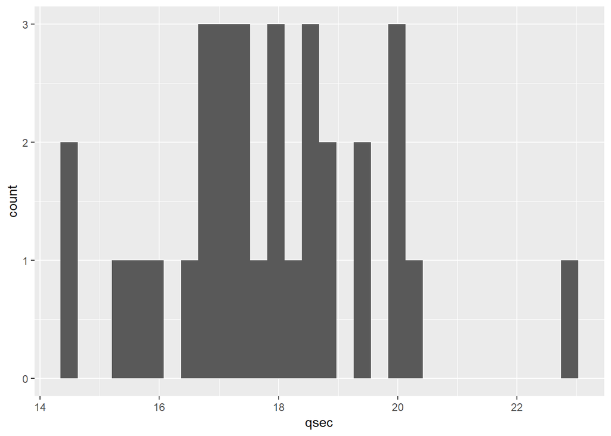

```r
  ggplot(mtcars) +
   geom_histogram(aes(qsec))
```

E agora, reestruturando a primeira linha segundo a lógica pipe, diminuindo o intervalo de quebra do histograma (que tem 30 por default), e alguns parâmetros estéticos:

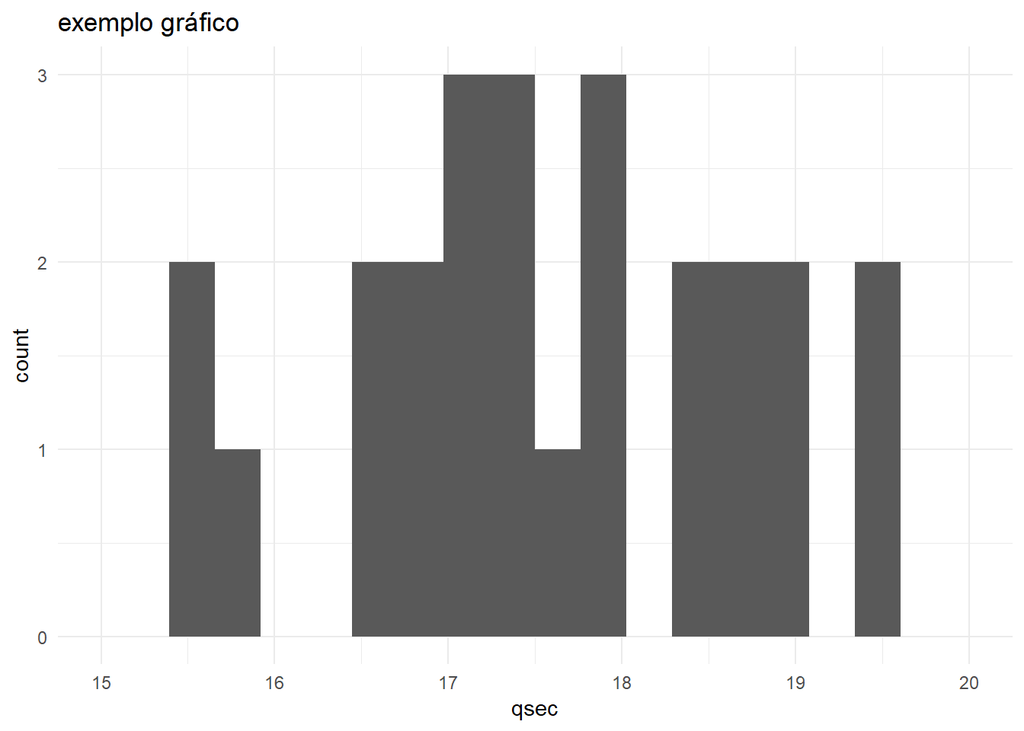

```r
  mtcars %>%
   ggplot() +
     geom_histogram(aes(qsec), bins = 20) +
     labs(title = "exemplo gráfico") +
     scale_x_continuous(limits = c(15,20)) +
     theme_minimal()
```

Visando ilustrar outras funcionalidades do `ggplot2` segue um exemplo em que a visualização é dada em termos da variável `mpg` por `disp`, segmentando por `vs` e modelando segundo para um dos níveis de `cyl` - note que ambas as variáveis de segmentaçao são originalmente numéricas e, portanto, precisam ser redefinidas como fatores, visando permitir a leitura:

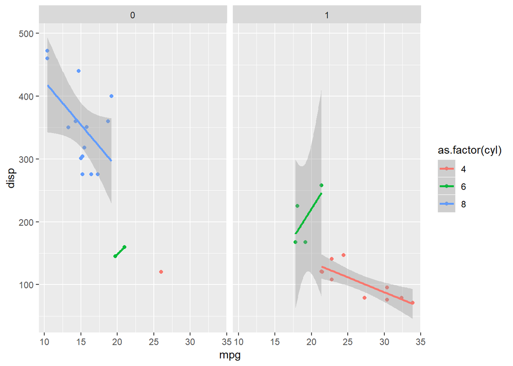

```r
#exemplo: gráfico ggplot
  mtcars %>%
    ggplot(aes(x = mpg, y = disp, color = as.factor(cyl))) +
    geom_point() +
    facet_grid(~as.factor(vs)) +
    stat_smooth(method = 'lm')
```

Adicionalmente, segue um exemplo considerando a base `diamonds`, onde o interesse é entender a distribuição da variável `cut` em relação à `clarity`, ou ambas quanto a `count`:

```r
#visualização dos dados
  diamonds %>% glimpse
  #> Observations: 53,940
  #> Variables: 10
  #> $ carat   <dbl> 0.23, 0.21, 0.23, 0.29, 0.31, 0.24, 0.24, 0.26, 0.22, ...
  #> $ cut     <ord> Ideal, Premium, Good, Premium, Good, Very Good, Very G...
  #> $ color   <ord> E, E, E, I, J, J, I, H, E, H, J, J, F, J, E, E, I, J, ...
  #> $ clarity <ord> SI2, SI1, VS1, VS2, SI2, VVS2, VVS1, SI1, VS2, VS1, SI...
  #> $ depth   <dbl> 61.5, 59.8, 56.9, 62.4, 63.3, 62.8, 62.3, 61.9, 65.1, ...
  #> $ table   <dbl> 55, 61, 65, 58, 58, 57, 57, 55, 61, 61, 55, 56, 61, 54...
  #> $ price   <int> 326, 326, 327, 334, 335, 336, 336, 337, 337, 338, 339,...
  #> $ x       <dbl> 3.95, 3.89, 4.05, 4.20, 4.34, 3.94, 3.95, 4.07, 3.87, ...
  #> $ y       <dbl> 3.98, 3.84, 4.07, 4.23, 4.35, 3.96, 3.98, 4.11, 3.78, ...
  #> $ z       <dbl> 2.43, 2.31, 2.31, 2.63, 2.75, 2.48, 2.47, 2.53, 2.49, ...
```

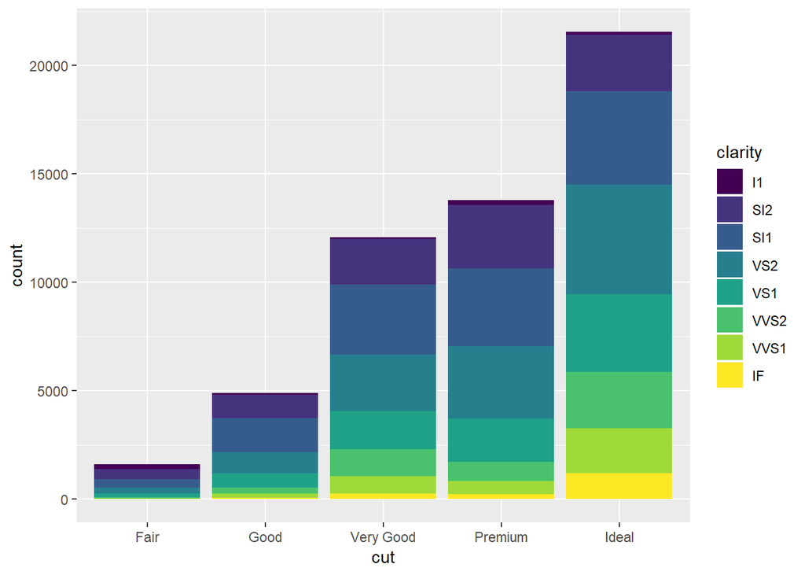

```r
# visualização 1
  diamonds %>%
    ggplot(aes(x = cut, fill = clarity)) +
    geom_bar()
```

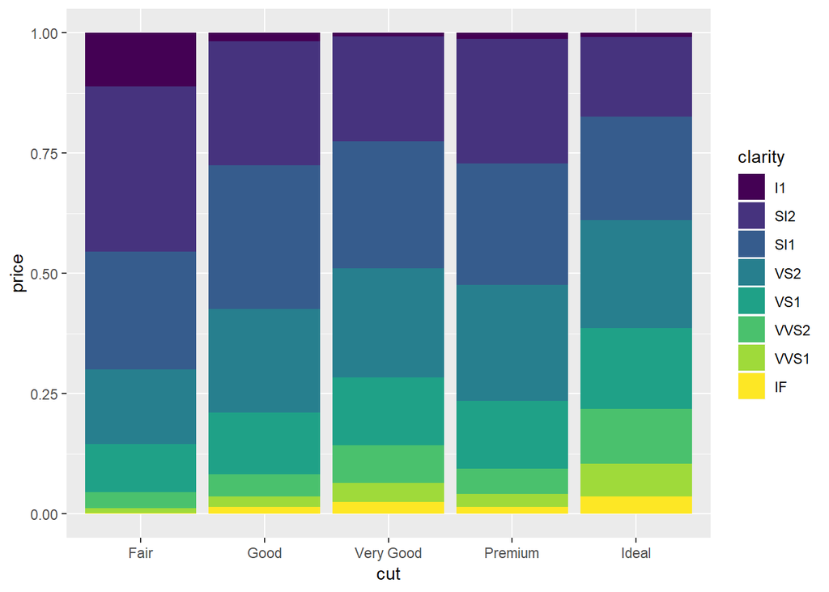

```r
# visualização 2
  diamonds %>%
    ggplot(aes(x = cut,  y = price)) +
    geom_bar(aes(fill = clarity),
             stat = "identity",
             position = "fill")
```

```r
economics
  #> # A tibble: 574 x 6
  #>    date         pce    pop psavert uempmed unemploy
  #>    <date>     <dbl>  <int>   <dbl>   <dbl>    <int>
  #>  1 1967-07-01  507. 198712    12.5     4.5     2944
  #>  2 1967-08-01  510. 198911    12.5     4.7     2945
  #>  3 1967-09-01  516. 199113    11.7     4.6     2958
  #>  4 1967-10-01  513. 199311    12.5     4.9     3143
  #>  5 1967-11-01  518. 199498    12.5     4.7     3066
  #>  6 1967-12-01  526. 199657    12.1     4.8     3018
  #>  7 1968-01-01  532. 199808    11.7     5.1     2878
  #>  8 1968-02-01  534. 199920    12.2     4.5     3001
  #>  9 1968-03-01  545. 200056    11.6     4.1     2877
  #> 10 1968-04-01  545. 200208    12.2     4.6     2709
  #> # ... with 564 more rows
```

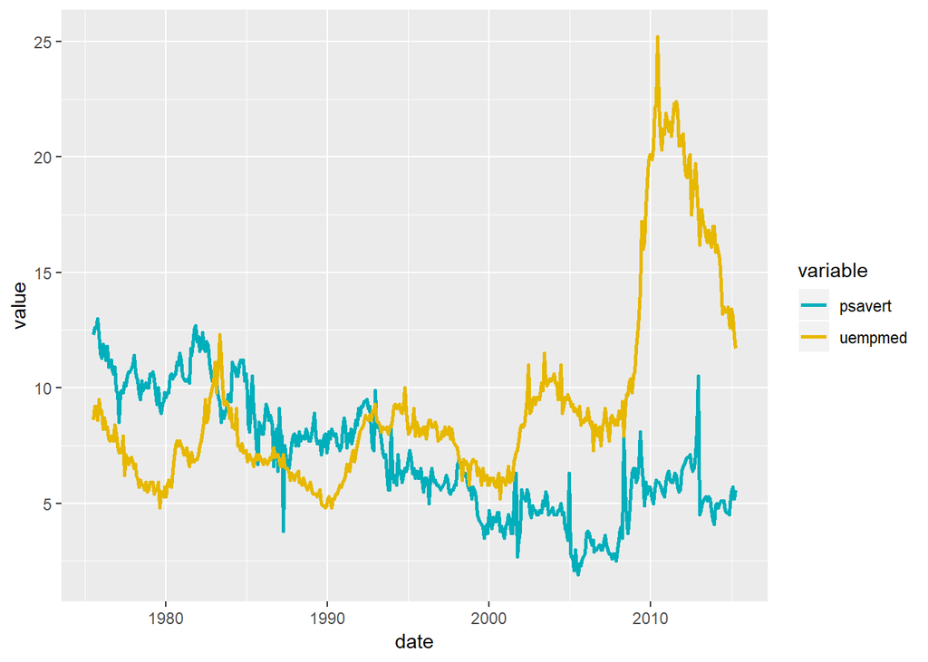

```r
economics %>%
  select(date, psavert, uempmed) %>%
  filter(date>1990) %>%
  gather(key = "variable", value = "value", -date) %>%
  ggplot(aes(x = date, y = value)) +
  geom_line(aes(color = variable), size = 1) +
  scale_color_manual(values = c("#00AFBB", "#E7B800"))
```

## 4.6 Modelagem

Após um entendimento mais profundo sobre os dados, seu comportamento, natureza e especificidades, podemos passar para a fase de modelagem. Assim, tendo as perguntas bem especificadas, podemos utilizar um modelo para respondê-las. No `tidyverse` a biblioteca `broom` é direcionada para esta etapa da análise, porém de um ponto de vista de integração. Isto porque tem como finalidade transformar resultados de modelos estatísticos e de machine learning em objetos com formato *tidy*, facilitando desde o entendimento e comunicação resultado, visto a integração com as muitas ferramentas do `tidyverse`, quanto a comparação entre diferentes modelos. O R possui como uma de suas bibliotecas default o `stats`, contemplando uma série de funções estatísticas, como, por exemplo, para o ajuste de um modelo de regressão linear simples:

```r
#exemplo: regressão linear simples
  fit <- lm(Sepal.Width ~ Petal.Length + Petal.Width, data = iris)
#e ao invés de visulizar os dados com os comandos abaixo
  fit
  #>
  #> Call:
  #> lm(formula = Sepal.Width ~ Petal.Length + Petal.Width, data = iris)
  #>
  #> Coefficients:
  #>  (Intercept)  Petal.Length   Petal.Width
  #>       3.5870       -0.2571        0.3640
  summary(fit)
  #>
  #> Call:
  #> lm(formula = Sepal.Width ~ Petal.Length + Petal.Width, data = iris)
  #>
  #> Residuals:
  #>      Min       1Q   Median       3Q      Max
  #> -1.06198 -0.23389  0.01982  0.20580  1.13488
  #>
  #> Coefficients:
  #>              Estimate Std. Error t value Pr(>|t|)
  #> (Intercept)   3.58705    0.09373  38.272  < 2e-16 ***
  #> Petal.Length -0.25714    0.06691  -3.843  0.00018 ***
  #> Petal.Width   0.36404    0.15496   2.349  0.02014 *
  #> ---
  #> Signif. codes:  0 '***' 0.001 '**' 0.01 '*' 0.05 '.' 0.1 ' ' 1
  #>
  #> Residual standard error: 0.3893 on 147 degrees of freedom
  #> Multiple R-squared:  0.2131,   Adjusted R-squared:  0.2024
  #> F-statistic:  19.9 on 2 and 147 DF,  p-value: 2.238e-08

#podemos utilizar um dos comandos da biblioteca `broom`
  broom::tidy(fit)
  #> # A tibble: 3 x 5
  #>   term         estimate std.error statistic  p.value
  #>   <chr>           <dbl>     <dbl>     <dbl>    <dbl>
  #> 1 (Intercept)     3.59     0.0937     38.3  2.51e-78
  #> 2 Petal.Length   -0.257    0.0669     -3.84 1.80e- 4
  #> 3 Petal.Width     0.364    0.155       2.35 2.01e- 2
```

Em relação à modelagem em si, visto ser algo que demanda conhecimentos prévios, não iremos nos aprofundar. Contudo segue uma lista com opções de bibliotecas para algumas metodologias/áreas:

- Árvore de Decisão - `part` e `rpart`
- Clusterização - `stats`, `cluster` e `fpc`
- Deep Learning - `keras`
- Random Forest - `randomForest`
- Redes Neurais - `nnet`, `neuralnet` e `RSNNS`
- Regressões - `stats`, `nlme` e `gbm`
- Séries Temporais - `forest` e `dtw`
- Text Mining - `tm` e `wordcloud`
- Validação Cruzada - `caret`

## 4.7 Programação

Como ferramenta transversal a todas as etapas do workflow de análise, temos a programação funcional, que permite a criação de códigos mais rápidos, simples e reproduzíveis. No contexto do `tidyverse` a biblioteca `purrr` disponibiliza de uma série de funcionalidades visando aprimorar a programação funcional no R. Como principal função temos o `map()`, transformando a sua entrada por meio da aplicação de uma função a cada elemento, e retornando uma lista com o mesmo comprimento que a entrada:

```r
#exemplo: , contabilização de tal identificação de dados faltantes por coluna,
  starwars %>%
    map(is.na) %>% #identificação de quais elementos, de cada coluna, são NA's
    map(sum) %>% #contabilização dos dados faltantes por coluna
    glimpse() #sumarização do resultado
  #> List of 13
  #>  $ name      : int 0
  #>  $ height    : int 6
  #>  $ mass      : int 28
  #>  $ hair_color: int 5
  #>  $ skin_color: int 0
  #>  $ eye_color : int 0
  #>  $ birth_year: int 44
  #>  $ gender    : int 3
  #>  $ homeworld : int 10
  #>  $ species   : int 5
  #>  $ films     : int 0
  #>  $ vehicles  : int 0
  #>  $ starships : int 0

#outras opções de sintaxe para obter o mesmo resultado
  #starwars %>% map(~sum(is.na(.)))
  #starwars %>% map( function(x) sum(is.na(x)) )
```

O `map()` retorna listas por default, para que o resultado tenha outra estrutura/classe, podemos utilizar funções como: `map_dbl` que retorna um vetor número, `map_dfc` para um data.frame que combina os resultados por coluna, entre outras opções. Adicionalmente temos recursos como:

- `walk()` - similar ao `map`, porém sem ter o retorno da lista no console
- `pmap()` - aplica uma função a um grupo de elementos de um grupo de listas
- `append()` - adiciona valores ao fim de uma lista

```r
#exemplo: para visulizar todos os arquivos de um dado diretório
  list.files("\diretório", pattern='*.xlsx') %>%
    map(read_excel) %>%
    walk(glimpse)
```

## 4.8 Comunicação

Por fim temos a apresentação dos resultados, uma parte crítica do processo, visto que, usualmente, é neste momento que toda a análise passa a ter um significado prático. Para tal podemos exportar as informações de interesse para outras ferramentas, como excel, power point, ou etc, o que não costuma ser muito prático. Como alternativa podemos fazer a análise e montar o report conjuntamente pelo R, garantindo reprodutibilidade e histórico, por meio do Rmarkdown. Tal recurso é uma extensão do R que permite que padrões básicos de formatação sejam utilizados, além de pedaços de código, imagens, e etc, possibilitando a geração de diferentes tipos de documentos a partir do Script do R:

[figure not shown]

RMarkdown

Para criar tais arquivos basta ir em ‘File > New File > R Markdown …’, preencher as especificações do Documento, e então apertar o botão Knit, ou o atalho ‘Ctrl + Shift + K’.

Além do RMarkdown, temos também ferramentas como o Shiny - pacote usado para geração de gráficos e dashboards interativos. que permitem a construção de aplicações Web. Para tal, as ferramentas da biblioteca convertem os dados analisados e as funções de R para HTML, CSS e JavaScript, gerando arquivos que podem ser abertos e trabalhados em um navegador.

O Shiny é baseado em dois componentes principais: ‘server’, que é responsável pela lógica do programa, tratamento e exibição dos dados, e ‘ui’ (user interface) que é responsável por oferecer as interações necessárias com o usuário através do navegador. Ambos possuem métodos e funções prontas para uso para as funcionalidades mais populares.

[figure not shown]

RMarkdown + Shiny

# 5 R para Big Data

O R, por padrão, trabalha com dados carregados em memória, por meio de processamento sequencial, o que pode limita tanto o tamanho da base de dados que podemos trabalhar, quanto a velocidade de análise. Alternativas para quando estamos sob alguma destas limitações incluem: trabalhar com amostragens, usar um computador com mais recursos, acessar os dados considerando outras formas de leitura/processamento, ou segmentação de dados. Detalhando estas duas últimas opções temos:

- outras formas de acesso:
  - substituir os data.frames/tibbles pelo data.table, da biblioteca `data.table()`, uma vez que este trabalha com otimização de processamento e memória;
  - processar os dados em disco, ao invés da memória, por meio de bibliotecas como `bigmemory`, `ff` ou `RevoScaleR`;
  - dado que o R é por padrão uma linguagem interpretada, utilizar funções como `compile()` ou `enableJIT()` para acelerar o processamento de uma análise, principalmente se ela for executada repeditamente; e
  - utilizar pacotes que possibilitam paralelismo, como `Foreach` ou `Multicore`.
- segmentação: aqui podemos trabalhar “manualmente”, carregando sub-conjuntos das base de dados, analisando cada uma delas, e depois combinando os resultados. Ou carregar bibliotecas que permitam integração do R com o ecossistema de Big Data, permitindo a distribuição e análise de forma automática. O `RHadoop`, por exemplo, é um conjunto de pacotes que permite conectar o ambiente R em clusters HDFS e HBASE para a execução de operações. Outra opção é o `sparklyr`, que possibilita a execução de comandos do R em clusters do Apache Spark. Tanto o `RHadoop` quanto o `sparklyr` possibilitam o uso de comandos do pacote `dplyr`, e a sintaxe do `tidyverse()`. Assim, as tecnologias se complementam: é possível escrever código de forma mais simples e rápida no R e executá-lo distribuidamente em grandes bases de dados no Hadoop ou Spark, e podemos alavancar os tradicionais sistemas de Big Data, integrando a eles as funcionalidades de análise e machine learning disponíveis no ecossistema do R.

Visando ilustrar a facilidade de tais integrações, segue a aplicação do mesmo conjunto de códigos anteriormente utilizados para a base `mtcars`:

```r
# #carregando da biblioteca após sua instalação
# library(sparklyr)
# library(dplyr)
#
# #criando uma conexão
# spark_conexao <- spark_connect(master = "local")
#
#  #transformando os dados de memŕia numa tbl_spark
#   mtcars_tbl <- sdf_copy_to(spark_conexao,
#                             mtcars, name = "mtcars_tbl",
#                             memory = FALSE)
#   class(mtcars_tbl)
#
#  #verificando a estrutura dos dados
#   mtcars_tbl %>% glimpse()
#
#  #selecionando alguma variaveis usando o dplyr
#   mtcars_reduzido <- mtcars_tbl %>%
#     select(mpg, hp)
#
#  #salvando o mtcars_reduzido em memória
#   mtcars_reduzido_ram <- collect(mtcars_reduzido)
#
# #Disconnect from Spark
# spark_disconnect(sc = spark_conexao)
```

Vale ressaltar que muitas das soluções que envolvem Big Data no R são novas, assim como o ecosistema de Big Data em si. E, portanto, estão em constante desenvolvimento, aumentando ainda mais a importância de manter o tracking de melhorias e correções dos pacotes. Vale ressaltar que mesmo com toda a necessidade de ajustes aqui apresentada, a quantidade de recursos que o R oferece para o flow da Ciência de Dados, faz com que grandes empresas, como Google, Microsoft, Bank of America e Shell, optem por trabalhar com a linguagem R.

# 6 Considerações Finais

Além das soluções e bibliotecas aqui comentados, é importante lembrar que o R oferece muitas formas de completar uma mesma atividade. Sendo assim, é sempre recomendado que procure opções para otimizar sua rotina. Seguem abaixo as algumas referências open-source para o aprofundamento dos pontos aqui listados:

- R for data science: https://r4ds.had.co.nz/introduction.html
- Advanced R: http://adv-r.had.co.nz/
- Hands-On Programming with R: https://rstudio-education.github.io/hopr/
- Curso-R: https://www.curso-r.com/material/

Vamos agora fazer um ciclo de análises considerando arquivos do Santander.

Boa sorte!

# 7 Apêndice - Tratamento de exceções

Chamamos de exceção qualquer condição anormal que possa aparecer quando estamos executando um programa de computador. Normalmente, esses erros acontecem por fatores externos do ponto de vista do código, como valores ou tipos não suportados passados para uma função, necessidade de leitura ou gravação de arquivos no sistema operacional, necessidade de conexão com a internet para obter algum dado.

As linguagens costumam ter formas de tratar as exceções, ou seja, métodos e funções que possam ser usados para que o programa não quebre a execução, não apresente erros abruptos ou até mesmo continue a partir do ponto em que o erro ocorreu. O tratamento de exceções em R é feito utilizando a função tryCatch. A sintaxe da função é:

```r
result = tryCatch(
  {
    #Código a ser executado
  },
  warning = function(condição) {
      #Código a ser executado caso ocorra algum aviso (warning)
  },
  error = function(condição) {
      #Código a ser executado caso ocorra algum erro
  },
  finally={
     # Código a sempre ser executado após um dos três blocos acima.
  }
)
```

Por exemplo, vamos escrever um código que retorna para uma variável as linhas de um arquivo lido de uma url:

```r
arquivo <- function(url) {
    linhas <- tryCatch(
        {
            message("Tentando ler o arquivo")
            readLines(con=url)
         },
        error=function(condicao) {
            message(paste("O caminho não pode ser acessado: ", url))
            message("Mensagem de erro original: ")
            message(condicao)
            return(NA)
        },
        warning=function(condicao) {
            message("Warnings foram gerados ao ler a url:")
            message(condicao)
            return(NULL)
        },
        finally={
           message("Fim da execução")
        }
    )
    return(linhas)
}
```

Caso o arquivo consiga ser lido, a última linha do primeiro bloco ( o resultado de readLines ) será retornado. Se ocorrer um erro, as mensagens de erro são exibidas e é retornado o valor NA. Se ocorrer algum warning, as mensagens correspondentes são enviadas e a função retorna NULL. Independente do valor de retorno, a mensagem de fim da execução será exibida ao final. É importante utilizar blocos de tratamento de exceção toda vez que não houver certeza sobre as condições necessárias para execução do código. Uma boa escolha de alternativas em caso de erros ou problemas faz com que o programa seja executado com maior confiabilidade, além de melhorar a legibilidade e diminuir o tempo gasto para correção desses erros e problemas.